# Book Recommendation System

### Recommendation systems :

are among the most popular applications of data science. They are used to predict the Rating or Preference that a user would give to an item.

Almost every major company has applied them in some form or the other: Amazon uses it to suggest products to customers, YouTube uses it to decide which video to play next on auto play, and Facebook uses it to recommend pages to like and people to follow.

### 1. import library and data¶

```python
import pandas as pd
import numpy as np
import matplotlib.pyplot as plt
```

```python
books = pd.read_csv('BX_Books.csv', sep=';', encoding="latin-1")
books.columns = ['ISBN', 'bookTitle', 'bookAuthor', 'yearOfPublication', 'publisher', 'imageUrlS', 'imageUrlM', 'imageUrlL']
```

```python
books.head()
```

|  | ISBN | bookTitle | bookAuthor | yearOfPublication | publisher | imageUrlS | imageUrlM | imageUrlL |
| --- | --- | --- | --- | --- | --- | --- | --- | --- |
| 0 | 0195153448 | Classical Mythology | Mark P. O. Morford | 2002 | Oxford University Press | http://images.amazon.com/images/P/0195153448.0... | http://images.amazon.com/images/P/0195153448.0... | http://images.amazon.com/images/P/0195153448.0... |
| 1 | 0002005018 | Clara Callan | Richard Bruce Wright | 2001 | HarperFlamingo Canada | http://images.amazon.com/images/P/0002005018.0... | http://images.amazon.com/images/P/0002005018.0... | http://images.amazon.com/images/P/0002005018.0... |
| 2 | 0060973129 | Decision in Normandy | Carlo D'Este | 1991 | HarperPerennial | http://images.amazon.com/images/P/0060973129.0... | http://images.amazon.com/images/P/0060973129.0... | http://images.amazon.com/images/P/0060973129.0... |
| 3 | 0374157065 | Flu: The Story of the Great Influenza Pandemic... | Gina Bari Kolata | 1999 | Farrar Straus Giroux | http://images.amazon.com/images/P/0374157065.0... | http://images.amazon.com/images/P/0374157065.0... | http://images.amazon.com/images/P/0374157065.0... |
| 4 | 0393045218 | The Mummies of Urumchi | E. J. W. Barber | 1999 | W. W. Norton & Company | http://images.amazon.com/images/P/0393045218.0... | http://images.amazon.com/images/P/0393045218.0... | http://images.amazon.com/images/P/0393045218.0... |

```python
users = pd.read_csv('BX-Users.csv', sep=';', encoding="latin-1")
users.columns = ['userID', 'Location', 'Age']
users.head()
```

|  | userID | Location | Age |
| --- | --- | --- | --- |
| 0 | 1 | nyc, new york, usa | NaN |
| 1 | 2 | stockton, california, usa | 18.0 |
| 2 | 3 | moscow, yukon territory, russia | NaN |
| 3 | 4 | porto, v.n.gaia, portugal | 17.0 |
| 4 | 5 | farnborough, hants, united kingdom | NaN |

```python
ratings = pd.read_csv('BX-Book-Ratings.csv', sep=';', encoding="latin-1")
ratings.columns = ['userID', 'ISBN', 'bookRating']
ratings.head()
```

|  | userID | ISBN | bookRating |
| --- | --- | --- | --- |
| 0 | 276725 | 034545104X | 0 |
| 1 | 276726 | 0155061224 | 5 |
| 2 | 276727 | 0446520802 | 0 |
| 3 | 276729 | 052165615X | 3 |
| 4 | 276729 | 0521795028 | 6 |

```python
print(ratings.shape)
print(list(ratings.columns))
```

```
(1149780, 3)
['userID', 'ISBN', 'bookRating']
```

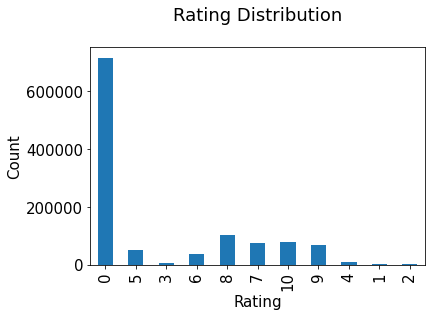

```python
plt.rc("font", size=15)
ratings.bookRating.value_counts(sort=False).plot(kind='bar')
plt.title('Rating Distribution\n')
plt.xlabel('Rating')
plt.ylabel('Count')
plt.show()
```

```python
print(books.shape)
print(list(books.columns))
```

```
(271379, 8)
['ISBN', 'bookTitle', 'bookAuthor', 'yearOfPublication', 'publisher', 'imageUrlS', 'imageUrlM', 'imageUrlL']
```

```python
print(users.shape)
print(list(users.columns))
```

```
(278858, 3)
['userID', 'Location', 'Age']
```

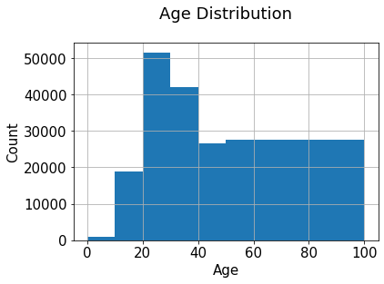

```python
users.Age.hist(bins=[0, 10, 20, 30, 40, 50, 100])
plt.title('Age Distribution\n')
plt.xlabel('Age')
plt.ylabel('Count')
plt.show()
```

```python
counts1 = ratings['userID'].value_counts()
ratings = ratings[ratings['userID'].isin(counts1[counts1 >= 200].index)]
counts = ratings['bookRating'].value_counts()
ratings = ratings[ratings['bookRating'].isin(counts[counts >= 100].index)]
```

#### Collaborative Filtering Using k-Nearest Neighbors (kNN)

kNN is a machine learning algorithm to find clusters of similar users based on common book ratings, and make predictions using the average rating of top-k nearest neighbors.

For example, we first present ratings in a matrix with the matrix having one row for each item (book) and one column for each user.

```python
combine_book_rating = pd.merge(ratings, books, on='ISBN')
columns = ['yearOfPublication', 'publisher', 'bookAuthor', 'imageUrlS', 'imageUrlM', 'imageUrlL']
combine_book_rating = combine_book_rating.drop(columns, axis=1)
print(combine_book_rating.head().to_markdown())
```

```
|    |   userID | ISBN       |   bookRating | bookTitle                                                                |
|---:|---------:|:-----------|-------------:|:-------------------------------------------------------------------------|
|  0 |   277427 | 002542730X |           10 | Politically Correct Bedtime Stories: Modern Tales for Our Life and Times |
|  1 |     3363 | 002542730X |            0 | Politically Correct Bedtime Stories: Modern Tales for Our Life and Times |
|  2 |    11676 | 002542730X |            6 | Politically Correct Bedtime Stories: Modern Tales for Our Life and Times |
|  3 |    12538 | 002542730X |           10 | Politically Correct Bedtime Stories: Modern Tales for Our Life and Times |
|  4 |    13552 | 002542730X |            0 | Politically Correct Bedtime Stories: Modern Tales for Our Life and Times |
```

#### Now we will group by book titles and create a new column for total rating count.

```python
combine_book_rating = combine_book_rating.dropna(axis = 0, subset = ['bookTitle'])

book_ratingCount = (combine_book_rating.
     groupby(by = ['bookTitle'])['bookRating'].
     count().
     reset_index().
     rename(columns = {'bookRating': 'totalRatingCount'})
     [['bookTitle', 'totalRatingCount']]
    )
print(book_ratingCount.head())
```

```
                                           bookTitle  totalRatingCount
0   A Light in the Storm: The Civil War Diary of ...                 2
1                              Always Have Popsicles                 1
2               Apple Magic (The Collector's series)                 1
3   Beyond IBM: Leadership Marketing and Finance ...                 1
4   Clifford Visita El Hospital (Clifford El Gran...                 1
```

#### Now we will combine the rating data with the total rating count data, this gives us exactly what we need to find out which books are popular and filter out lesser-known books.

```python
rating_with_totalRatingCount = combine_book_rating.merge(book_ratingCount, left_on = 'bookTitle', right_on = 'bookTitle', how = 'left')
print(rating_with_totalRatingCount.head())
```

```
   userID        ISBN  bookRating  \
0  277427  002542730X          10
1    3363  002542730X           0
2   11676  002542730X           6
3   12538  002542730X          10
4   13552  002542730X           0

                                           bookTitle  totalRatingCount
0  Politically Correct Bedtime Stories: Modern Ta...                82
1  Politically Correct Bedtime Stories: Modern Ta...                82
2  Politically Correct Bedtime Stories: Modern Ta...                82
3  Politically Correct Bedtime Stories: Modern Ta...                82
4  Politically Correct Bedtime Stories: Modern Ta...                82
```

```python
pd.set_option('display.float_format', lambda x: '%.3f' % x)
print(book_ratingCount['totalRatingCount'].describe())
```

```
count   160587.000
mean         3.044
std          7.428
min          1.000
25%          1.000
50%          1.000
75%          2.000
max        365.000
Name: totalRatingCount, dtype: float64
```

```python
print(book_ratingCount['totalRatingCount'].quantile(np.arange(.9, 1, .01)))
```

```
0.900    5.000
0.910    6.000
0.920    7.000
0.930    7.000
0.940    8.000
0.950   10.000
0.960   11.000
0.970   14.000
0.980   19.000
0.990   31.000
Name: totalRatingCount, dtype: float64
```

```python
popularity_threshold = 50
rating_popular_book = rating_with_totalRatingCount.query('totalRatingCount >= @popularity_threshold')
print(rating_popular_book.head())
```

```
   userID        ISBN  bookRating  \
0  277427  002542730X          10
1    3363  002542730X           0
2   11676  002542730X           6
3   12538  002542730X          10
4   13552  002542730X           0

                                           bookTitle  totalRatingCount
0  Politically Correct Bedtime Stories: Modern Ta...                82
1  Politically Correct Bedtime Stories: Modern Ta...                82
2  Politically Correct Bedtime Stories: Modern Ta...                82
3  Politically Correct Bedtime Stories: Modern Ta...                82
4  Politically Correct Bedtime Stories: Modern Ta...                82
```

#### Filter to users in US and Canada only

```python
combined = rating_popular_book.merge(users, left_on = 'userID', right_on = 'userID', how = 'left')

us_canada_user_rating = combined[combined['Location'].str.contains("usa|canada")]
us_canada_user_rating=us_canada_user_rating.drop('Age', axis=1)
print(us_canada_user_rating.head())
```

```
   userID        ISBN  bookRating  \
0  277427  002542730X          10
1    3363  002542730X           0
3   12538  002542730X          10
4   13552  002542730X           0
5   16795  002542730X           0

                                           bookTitle  totalRatingCount  \
0  Politically Correct Bedtime Stories: Modern Ta...                82
1  Politically Correct Bedtime Stories: Modern Ta...                82
3  Politically Correct Bedtime Stories: Modern Ta...                82
4  Politically Correct Bedtime Stories: Modern Ta...                82
5  Politically Correct Bedtime Stories: Modern Ta...                82

                        Location
0          gilbert, arizona, usa
1      knoxville, tennessee, usa
3          byron, minnesota, usa
4        cordova, tennessee, usa
5  mechanicsville, maryland, usa
```

#### Implementing kNN

We convert our table to a 2D matrix, and fill the missing values with zeros (since we will calculate distances between rating vectors).

We then transform the values(ratings) of the matrix dataframe into a scipy sparse matrix for more efficient calculations.

#### What is Sparse Data

Sparse data is data that has mostly unused elements (elements that don't carry any information ).

It can be an array like this one:

[1, 0, 2, 0, 0, 3, 0, 0, 0, 0, 0, 0]

- Sparse Data: is a data set where most of the item values are zero.
- Dense Array: is the opposite of a sparse array: most of the values are not zero.

In scientific computing, when we are dealing with partial derivatives in linear algebra we will come across sparse data.

SciPy has a module, scipy.sparse that provides functions to deal with sparse data.

There are primarily two types of sparse matrices that we use:

- CSC - Compressed Sparse Column. For efficient arithmetic, fast column slicing.
- CSR - Compressed Sparse Row. For fast row slicing, faster matrix vector products

Example:

Input: arr = np.array([0, 0, 0, 0, 0, 1, 1, 0, 2])

print(csr_matrix(arr))

Output:

- (0, 5) 1 #The 1. item is in row 0 position 5 and has the value 1.
- (0, 6) 1 #The 2. item is in row 0 position 6 and has the value 1.
- (0, 8) 2 #The 3. item is in row 0 position 8 and has the value 2.

From the result we can see that there are 3 items with value.

```python
from scipy.sparse import csr_matrix
us_canada_user_rating = us_canada_user_rating.drop_duplicates(['userID', 'bookTitle'])
us_canada_user_rating_pivot = us_canada_user_rating.pivot(index = 'bookTitle', columns = 'userID', values = 'bookRating').fillna(0)

us_canada_user_rating_matrix = csr_matrix(us_canada_user_rating_pivot.values)
print(us_canada_user_rating_matrix)
```

```
  (0, 0)	9.0
  (0, 15)	8.0
  (0, 34)	9.0
  (0, 37)	8.0
  (0, 51)	7.0
  (0, 115)	9.0
  (0, 131)	10.0
  (0, 142)	9.0
  (0, 157)	8.0
  (0, 181)	10.0
  (0, 201)	10.0
  (0, 224)	10.0
  (0, 302)	9.0
  (0, 319)	10.0
  (0, 399)	7.0
  (0, 450)	10.0
  (0, 491)	9.0
  (0, 498)	8.0
  (0, 571)	9.0
  (0, 628)	8.0
  (0, 633)	7.0
  (0, 684)	10.0
  (0, 725)	10.0
  (1, 10)	9.0
  (1, 37)	9.0
  :	:
  (744, 123)	5.0
  (744, 147)	9.0
  (744, 249)	8.0
  (744, 329)	2.0
  (744, 393)	8.0
  (745, 15)	8.0
  (745, 73)	10.0
  (745, 95)	5.0
  (745, 128)	6.0
  (745, 191)	7.0
  (745, 236)	8.0
  (745, 249)	9.0
  (745, 299)	10.0
  (745, 314)	9.0
  (745, 362)	7.0
  (745, 366)	9.0
  (745, 394)	7.0
  (745, 403)	10.0
  (745, 408)	8.0
  (745, 442)	10.0
  (745, 480)	8.0
  (745, 575)	10.0
  (745, 587)	8.0
  (745, 615)	10.0
  (745, 687)	9.0
```

```python
from sklearn.neighbors import NearestNeighbors

model_knn = NearestNeighbors(metric = 'cosine', algorithm = 'brute')
model_knn.fit(us_canada_user_rating_matrix)
print(model_knn)
```

```
NearestNeighbors(algorithm='brute', metric='cosine')
```

```python
query_index = np.random.choice(us_canada_user_rating_pivot.shape[0])
print(query_index)
print(us_canada_user_rating_pivot.iloc[query_index,:].values.reshape(1,-1))
distances, indices = model_knn.kneighbors(us_canada_user_rating_pivot.iloc[query_index,:].values.reshape(1, -1), n_neighbors = 6)
us_canada_user_rating_pivot.index[query_index]
```

[output not shown]

```
'The Pelican Brief'
```

```python
for i in range(0, len(distances.flatten())):
    if i == 0:
        print('Recommendations for {0}:\n'.format(us_canada_user_rating_pivot.index[query_index]))
    else:
        print('{0}: {1}, with distance of {2}:'.format(i, us_canada_user_rating_pivot.index[indices.flatten()[i]], distances.flatten()[i]))
```

```
Recommendations for The Pelican Brief:

1: The Client, with distance of 0.5753815832029239:
2: The Firm, with distance of 0.5763752458293947:
3: A Time to Kill, with distance of 0.5836862592221315:
4: The Rainmaker, with distance of 0.6483484401118922:
5: The Partner, with distance of 0.651616387369816:
```